# cnmf_programs_in_ACC

Avishai Wizel

2023-03-23

```r
all_acc_cancer_cells = readRDS("./Data/acc_cancer_cells_V3.RDS")
```

```r
  original_myo_genes = c("TP63", "TP73", "CAV1", "CDH3", "KRT5", "KRT14", "ACTA2", "TAGLN", "MYLK", "DKK3")
  original_lum_genes = c("KIT", "EHF", "ELF5", "KRT7", "CLDN3", "CLDN4", "CD24", "LGALS3", "LCN2", "SLPI")
  orig_myoscore=apply(all_acc_cancer_cells@assays[["RNA"]][original_myo_genes,],2,mean)
  orig_lescore=apply(all_acc_cancer_cells@assays[["RNA"]][original_lum_genes,],2,mean)
  all_acc_cancer_cells = AddMetaData(object = all_acc_cancer_cells,metadata = orig_lescore-orig_myoscore,col.name = "lum_over_myo")
    all_acc_cancer_cells = AddMetaData(object = all_acc_cancer_cells,metadata = orig_myoscore,col.name = "myo_score")
    all_acc_cancer_cells = AddMetaData(object = all_acc_cancer_cells,metadata = orig_lescore,col.name = "lum_score")
```

## Load object

```python
reticulate::repl_python()
from cnmf import cNMF
import pickle
nfeatures = "2K"
f = open('./Data/cNMF/HMSC_cNMF_' + nfeatures+ 'vargenes/cnmf_obj.pckl', 'rb')
cnmf_obj = pickle.load(f)
f.close()
```

```python
selected_k = 4
density_threshold = 0.1
cnmf_obj.consensus(k=selected_k, density_threshold=density_threshold,show_clustering=True)
usage_norm, gep_scores, gep_tpm, topgenes = cnmf_obj.load_results(K=selected_k, density_threshold=density_threshold)
```

```r
quit
gep_scores = py$gep_scores
gep_tpm = py$gep_tpm
all_metagenes= py$usage_norm
```

```r
no_neg <- function(x) {
  x = x + abs(min(x))
  x
}
gep_scores_norm = gep_scores

# gep_scores_norm = apply(gep_scores, MARGIN = 2, FUN = min_max_normalize)%>% as.data.frame()
#or:
gep_scores_norm = apply(gep_scores, MARGIN = 2, FUN = no_neg)%>% as.data.frame()

gep_scores_norm = sum2one(gep_scores_norm)
all_metagenes = expression_mult(gep_scores = gep_scores_norm,dataset = all_acc_cancer_cells,top_genes = T,z_score = F)
```

# Programs enrichments

```r
#Hallmarks:
plt_list = list()
for (i in 1:ncol(gep_scores)) {
  top_genes = gep_scores  %>%  arrange(desc(gep_scores[i])) #sort by score a
  top = head(rownames(top_genes),200) #take top top_genes_num
  res = genes_vec_enrichment(genes = top,background = rownames(gep_scores),homer = T,title =
                    i,silent = T,return_all = T)

  plt_list[[i]] = res$plt
}
p = ggarrange(plotlist  = plt_list)
print_tab(plt = p,title = "HALLMARK enrichment")
```

## HALLMARK enrichment

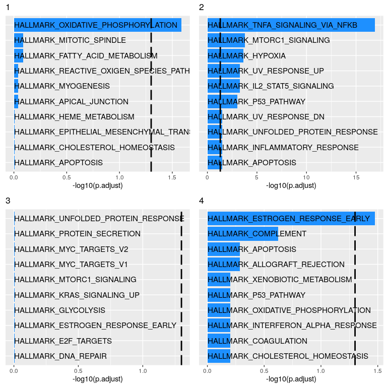

```r
#Canonical:
canonical_pathways = msigdbr(species = "Homo sapiens", category = "C2") %>% dplyr::filter(gs_subcat != "CGP") %>%  dplyr::distinct(gs_name, gene_symbol)

plt_list = list()
for (i in 1:ncol(gep_scores)) {
  top_genes = gep_scores  %>%  arrange(desc(gep_scores[i])) #sort by score a
  top = head(rownames(top_genes),200) #take top top_genes_num
  res = genes_vec_enrichment(genes = top,background = rownames(gep_scores),homer = T,title =
                    i,silent = T,return_all = T,custom_pathways = canonical_pathways)

  plt_list[[i]] = res$plt
}
p = ggarrange(plotlist  = plt_list)
print_tab(plt = p,title = "canonical pathway enrichment")
```

## canonical pathway enrichment

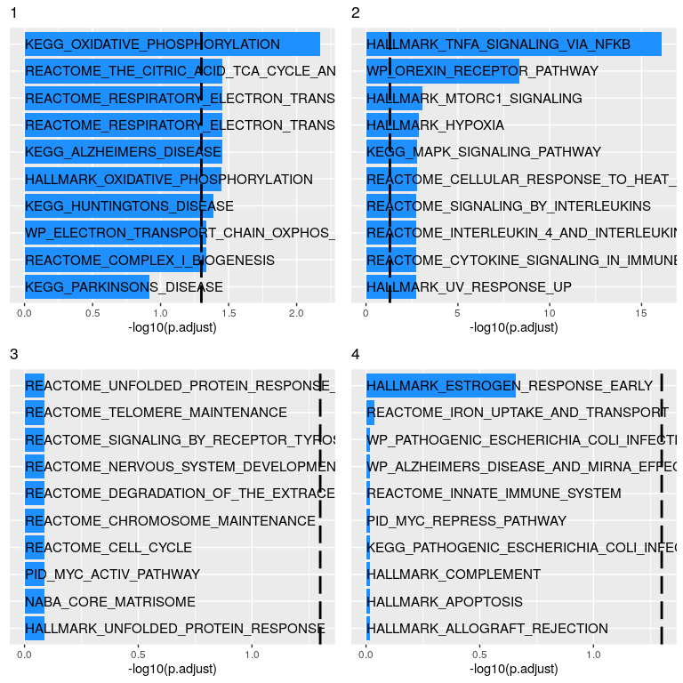

NA

## luminal and myo genes in score

```r
# lum genes in metagenes
message("lum genes in metagenes:")
```

```
lum genes in metagenes:
```

```r
for (i in 1:ncol(gep_scores)) {
  top_genes = gep_scores  %>%  arrange(desc(gep_scores[i])) #sort by score a
  top = head(rownames(top_genes),200) #take top top_genes_num
  cat(paste0("metagene ",i,": "))
  print(original_lum_genes[original_lum_genes %in% top])

}
```

```
metagene 1: [1] "KRT7" "SLPI"
metagene 2: [1] "CLDN4"
metagene 3: character(0)
metagene 4: [1] "KRT7"   "LGALS3" "LCN2"   "SLPI"
```

```r
cat("\n")
```

```r
# myo genes in metagenes
message("myo genes in metagenes:")
```

```
myo genes in metagenes:
```

```r
for (i in 1:ncol(gep_scores)) {
  top_genes = gep_scores  %>%  arrange(desc(gep_scores[i])) #sort by score a
  top = head(rownames(top_genes),200) #take top top_genes_num
  cat(paste0("metagene ",i,": "))
  print(original_myo_genes[original_myo_genes %in% top])

}
```

```
metagene 1: [1] "KRT14" "ACTA2" "DKK3"
metagene 2: character(0)
metagene 3: character(0)
metagene 4: character(0)
```

```r
cat("\n")
```

```r
notch_genes = c("JAG1","JAG2","NOTCH3","NOTCH2","NOTCH1","DLL1","MYB","HES4","HEY1","HEY2","NRARP")
# notch genes in metagenes
message("notch genes in metagenes:")
```

```
notch genes in metagenes:
```

```r
for (i in 1:ncol(gep_scores)) {
  top_genes = gep_scores  %>%  arrange(desc(gep_scores[i])) #sort by score a
  top = head(rownames(top_genes),200) #take top top_genes_num
  cat(paste0("metagene ",i,": "))
  print(notch_genes[notch_genes %in% top])

}
```

```
metagene 1: character(0)
metagene 2: character(0)
metagene 3: character(0)
metagene 4: character(0)
```

```r
cat("\n")
```

# Metagenes on ACC

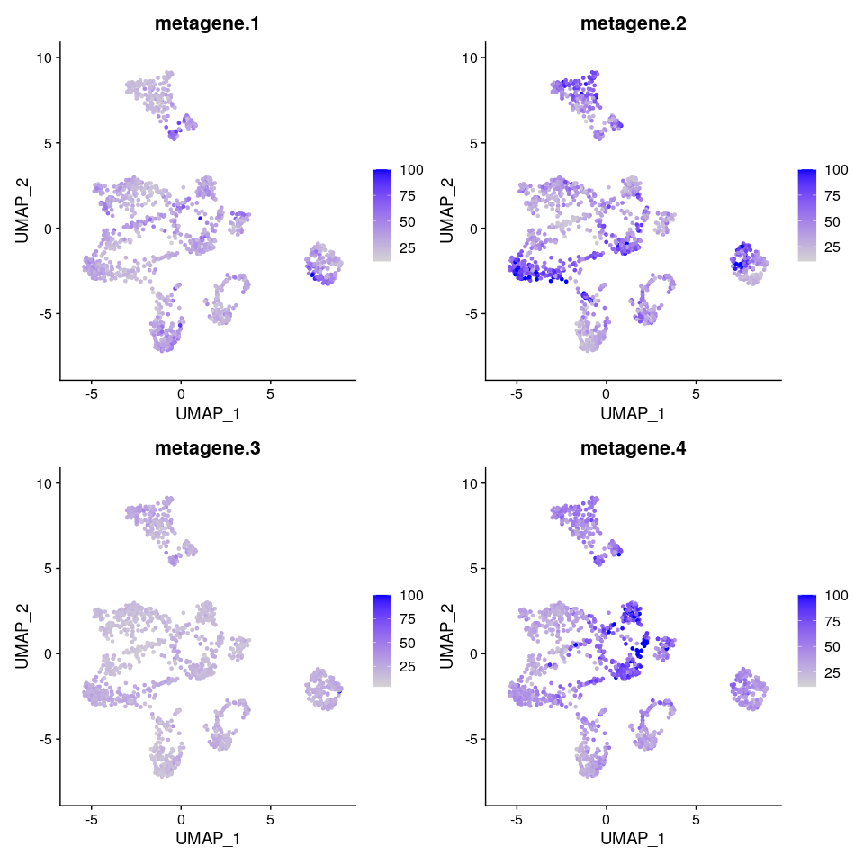

```r
# Make metagene names
for (i in 1:ncol(all_metagenes)) {
  colnames(all_metagenes)[i] = "metagene." %>% paste0(i)
}


#add each metagene to metadata
for (i in 1:ncol(all_metagenes)) {
  metage_metadata = all_metagenes %>% select(i)
  all_acc_cancer_cells = AddMetaData(object = all_acc_cancer_cells,metadata = metage_metadata)
}

FeaturePlot(object = all_acc_cancer_cells,features = colnames(all_metagenes),max.cutoff = 100)
```

```r
all_acc_cancer_cells = program_assignment(dataset = all_acc_cancer_cells,larger_by = 1.25,program_names = colnames(all_metagenes))
```

# UMAPS

```r
colors =  rainbow(all_acc_cancer_cells$program.assignment %>% unique() %>% length()-1)
colors = c(colors,"grey")
print_tab(plt = DimPlot(object = all_acc_cancer_cells,group.by = "program.assignment",cols =colors),title = "program.assignment")
```

## program.assignment

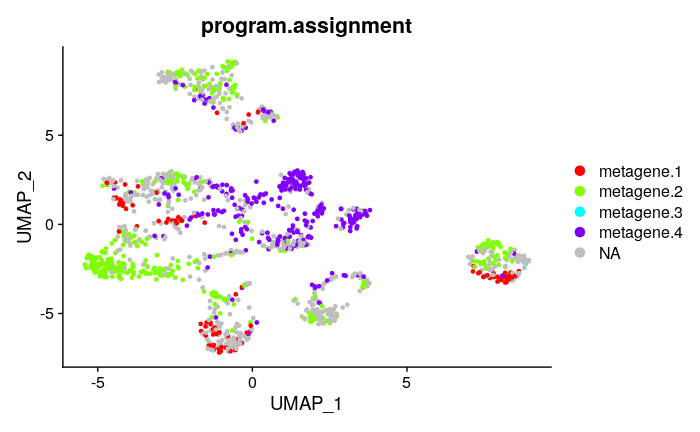

```r
print_tab(plt = DimPlot(object = all_acc_cancer_cells,group.by = "patient.ident"),title = "patient.ident")
```

## patient.ident

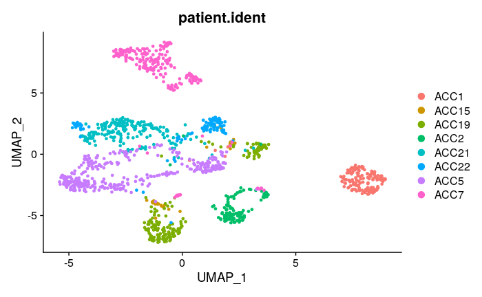

```r
print_tab(plt = FeaturePlot(object = all_acc_cancer_cells,features = "lum_score"),title = "lum_score")
```

## lum_score

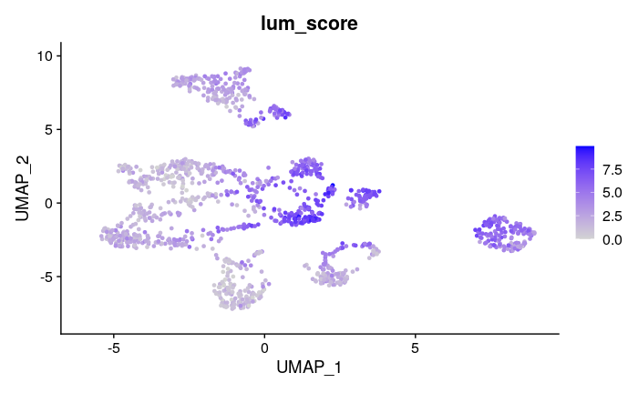

```r
print_tab(plt = FeaturePlot(object = all_acc_cancer_cells,features = "myo_score"),title = "myo_score")
```

## myo_score

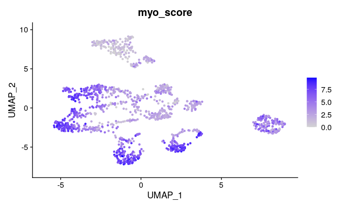

NA

# metagenes by lum_over_myo

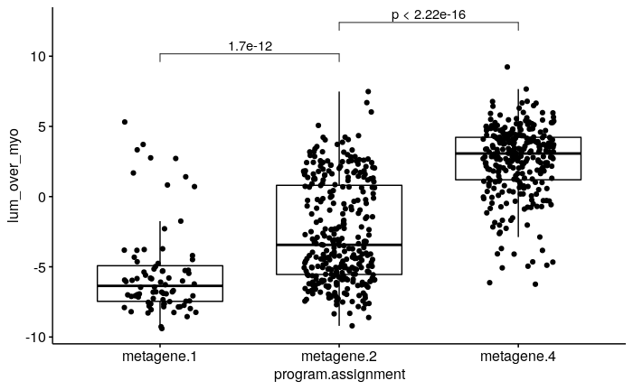

```r
acc_cancerCells_noACC1 = subset(all_acc_cancer_cells,subset = patient.ident!= "ACC1")

lumScore_vs_program = FetchData(object = acc_cancerCells_noACC1,vars = c("lum_over_myo","program.assignment"))
lumScore_vs_program$program.assignment <- factor(lumScore_vs_program$program.assignment, levels = c("metagene.1","metagene.2","metagene.4"))

lumScore_vs_program = lumScore_vs_program %>% dplyr::filter(program.assignment %in% c("metagene.1","metagene.2","metagene.4"))
ggboxplot(lumScore_vs_program, x = "program.assignment", y = "lum_over_myo",
          palette = "jco",
          add = "jitter")+ stat_compare_means(method = "wilcox.test",comparisons = list(c("metagene.1","metagene.2"),c("metagene.2","metagene.4")))
```

# Metagenes correlation with myo score

```r
for (metagene in c("metagene.1","metagene.2","metagene.4")) {
   lum_score_vs_programScore = FetchData(object = acc_cancerCells_noACC1,vars = c(metagene,"myo_score"))
  print_tab(plt =
    ggscatter(lum_score_vs_programScore, x = metagene, y = "myo_score",
            add = "reg.line", conf.int = TRUE,
            cor.coef = TRUE, cor.method = "pearson")
  ,title = metagene)
}
```

## metagene.1

`geom_smooth()` using formula ‘y ~ x’

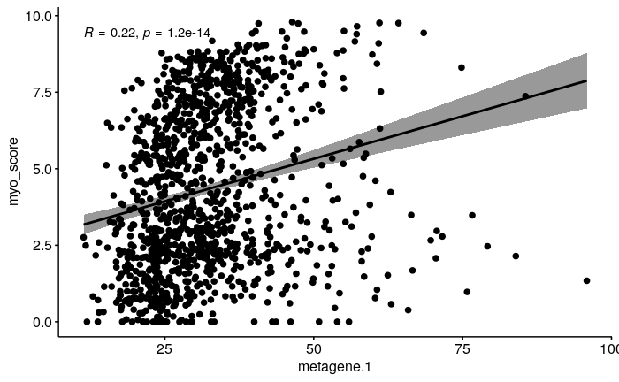

## metagene.2

`geom_smooth()` using formula ‘y ~ x’

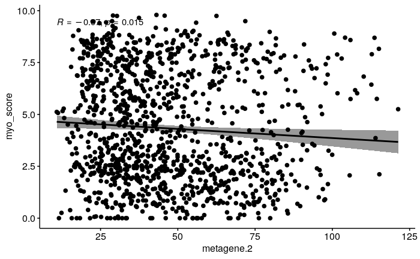

## metagene.4

`geom_smooth()` using formula ‘y ~ x’

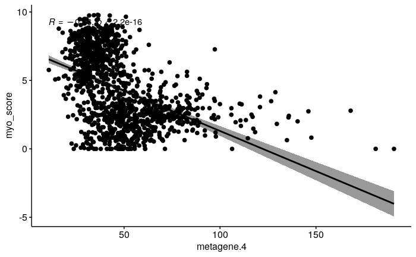

NA

```r
NA
```

# Metagenes correlation with lum score

```r
for (metagene in c("metagene.1","metagene.2","metagene.4")) {
   lum_score_vs_programScore = FetchData(object = acc_cancerCells_noACC1,vars = c(metagene,"lum_score"))
  print_tab(plt =
    ggscatter(lum_score_vs_programScore, x = metagene, y = "lum_score",
            add = "reg.line", conf.int = TRUE,
            cor.coef = TRUE, cor.method = "pearson")
  ,title = metagene)
}
```

## metagene.1

`geom_smooth()` using formula ‘y ~ x’

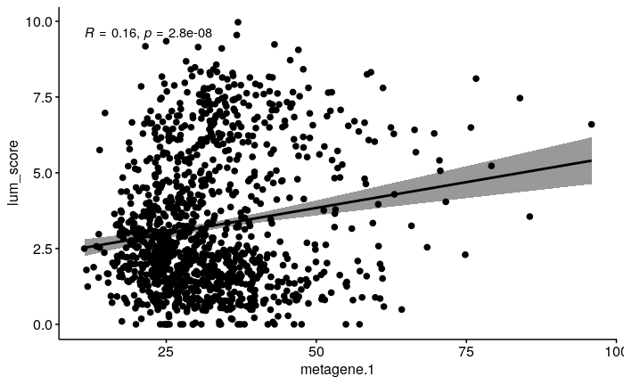

## metagene.2

`geom_smooth()` using formula ‘y ~ x’

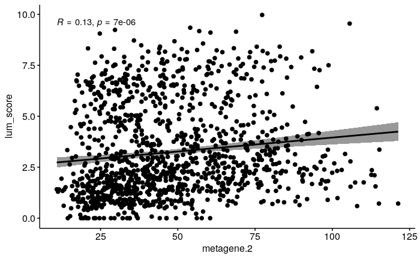

## metagene.4

`geom_smooth()` using formula ‘y ~ x’

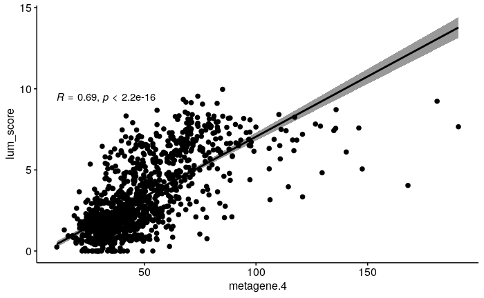

NA

```r
NA
```

# metagene 1 with myo genes

```r
for (gene in original_myo_genes) {

  lum_score_vs_programScore = FetchData(object = acc_cancerCells_noACC1,vars = c("metagene.1",gene))
p = ggscatter(lum_score_vs_programScore, x = "metagene.1", y = gene,
          add = "reg.line", conf.int = TRUE,
          cor.coef = TRUE, cor.method = "pearson")
print_tab(plt = p,title = gene)
}
```

## TP63

`geom_smooth()` using formula ‘y ~ x’

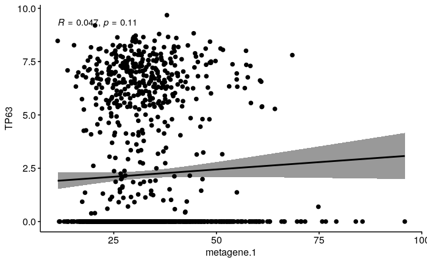

## TP73

`geom_smooth()` using formula ‘y ~ x’

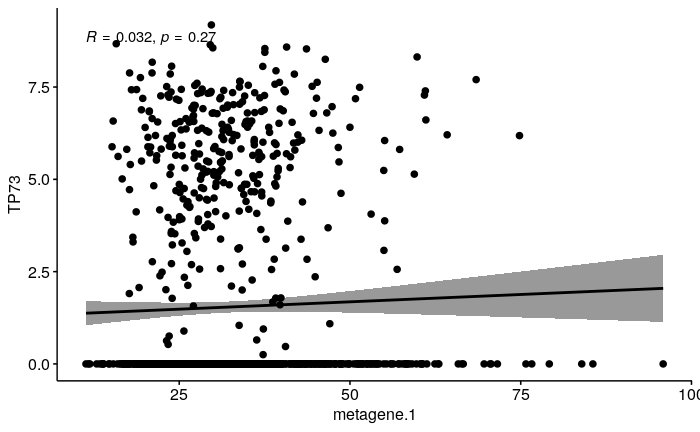

## CAV1

`geom_smooth()` using formula ‘y ~ x’

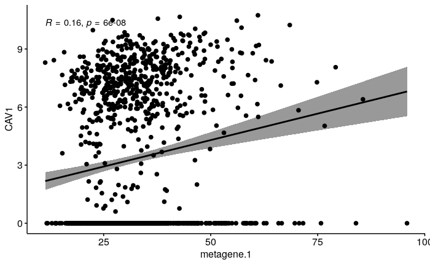

## CDH3

`geom_smooth()` using formula ‘y ~ x’

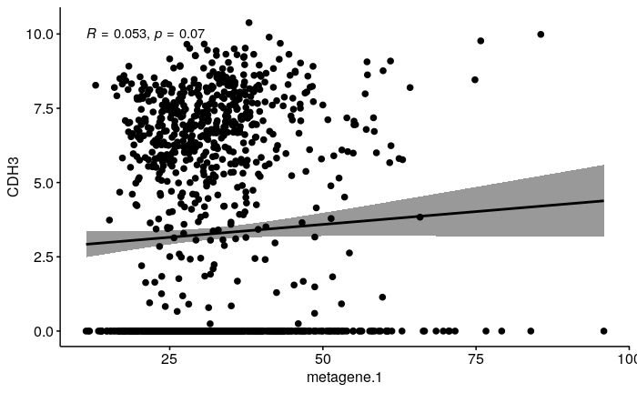

## KRT5

`geom_smooth()` using formula ‘y ~ x’

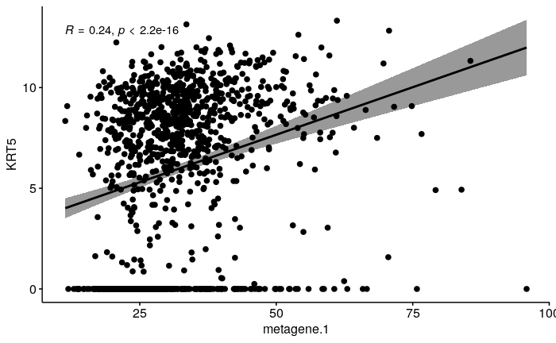

## KRT14

`geom_smooth()` using formula ‘y ~ x’

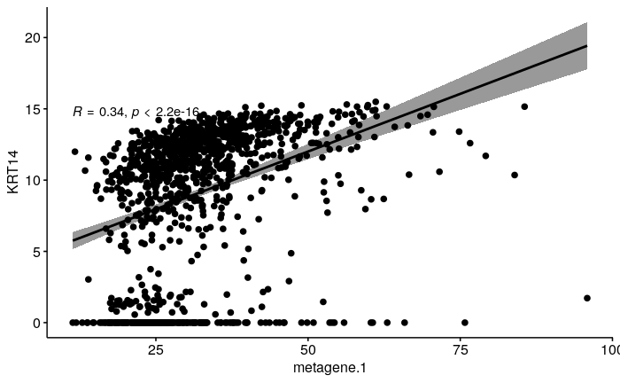

## ACTA2

`geom_smooth()` using formula ‘y ~ x’

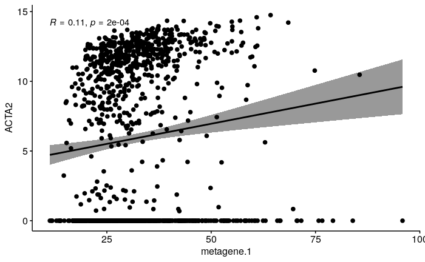

## TAGLN

`geom_smooth()` using formula ‘y ~ x’

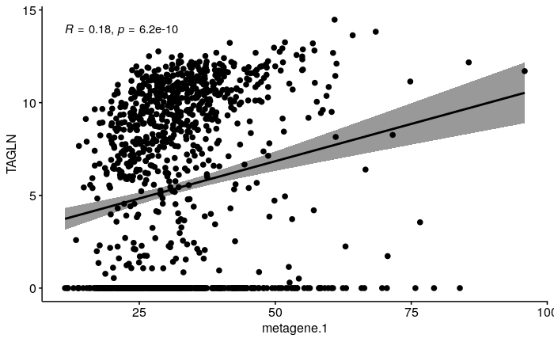

## MYLK

`geom_smooth()` using formula ‘y ~ x’

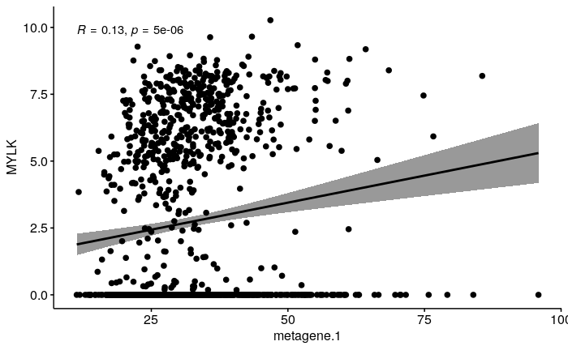

## DKK3

`geom_smooth()` using formula ‘y ~ x’

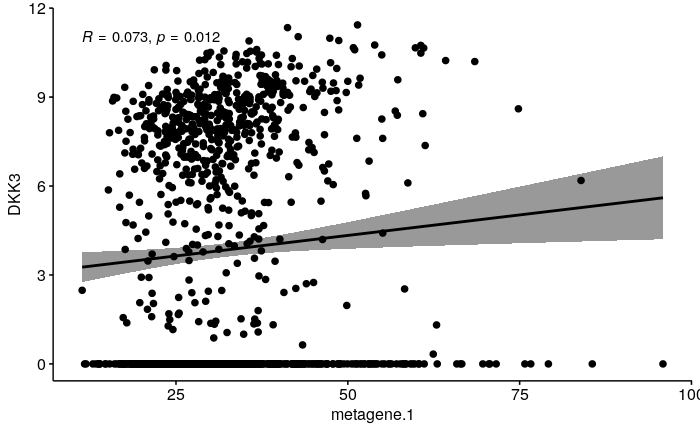

NA

# metagene 2 with myo genes

```r
for (gene in original_myo_genes) {

  lum_score_vs_programScore = FetchData(object = acc_cancerCells_noACC1,vars = c("metagene.2",gene))
p = ggscatter(lum_score_vs_programScore, x = "metagene.2", y = gene,
          add = "reg.line", conf.int = TRUE,
          cor.coef = TRUE, cor.method = "pearson")
print_tab(plt = p,title = gene)
}
```

## TP63

`geom_smooth()` using formula ‘y ~ x’

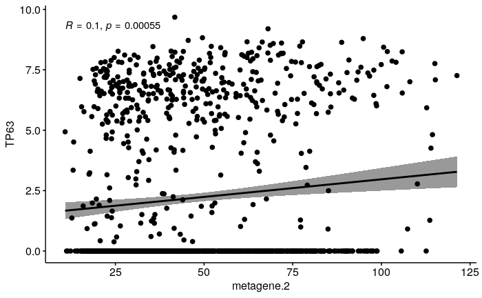

## TP73

`geom_smooth()` using formula ‘y ~ x’

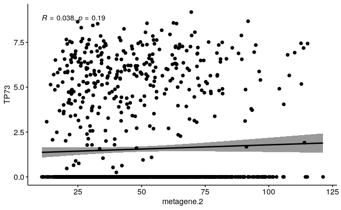

## CAV1

`geom_smooth()` using formula ‘y ~ x’

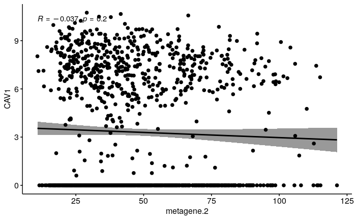

## CDH3

`geom_smooth()` using formula ‘y ~ x’

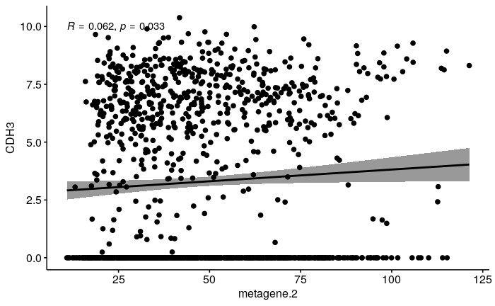

## KRT5

`geom_smooth()` using formula ‘y ~ x’

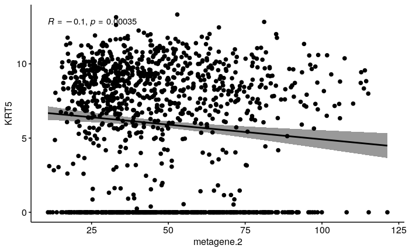